# Project 1

Siyu Zou

2023-09-11

### Project Data

```r
# tuesdata <- tidytuesdayR::tt_load("2022-01-18")
# chocolate <- tuesdata$chocolate


# tests if a directory named "data" exists locally
if (!dir.exists(here("data"))) {
    dir.create(here("data"))
}

# saves data only once (not each time you knit a R Markdown)
if (!file.exists(here("data", "chocolate.RDS"))) {
    url_csv <- "https://raw.githubusercontent.com/rfordatascience/tidytuesday/master/data/2022/2022-01-18/chocolate.csv"
    chocolate <- readr::read_csv(url_csv)

    # save the file to RDS objects
    saveRDS(chocolate, file = here("data", "chocolate.RDS"))
}

chocolate <- readRDS(here("data", "chocolate.RDS"))
as_tibble(chocolate)
```

```
## # A tibble: 2,530 × 10
##      ref compan…¹ compa…² revie…³ count…⁴ speci…⁵ cocoa…⁶ ingre…⁷ most_…⁸ rating
##    <dbl> <chr>    <chr>     <dbl> <chr>   <chr>   <chr>   <chr>   <chr>    <dbl>
##  1  2454 5150     U.S.A.     2019 Tanzan… Kokoa … 76%     3- B,S… rich c…   3.25
##  2  2458 5150     U.S.A.     2019 Domini… Zorzal… 76%     3- B,S… cocoa,…   3.5
##  3  2454 5150     U.S.A.     2019 Madaga… Bejofo… 76%     3- B,S… cocoa,…   3.75
##  4  2542 5150     U.S.A.     2021 Fiji    Matasa… 68%     3- B,S… chewy,…   3
##  5  2546 5150     U.S.A.     2021 Venezu… Sur de… 72%     3- B,S… fatty,…   3
##  6  2546 5150     U.S.A.     2021 Uganda  Semuli… 80%     3- B,S… mildly…   3.25
##  7  2542 5150     U.S.A.     2021 India   Anamal… 68%     3- B,S… milk b…   3.5
##  8   797 A. Morin France     2012 Bolivia Bolivia 70%     4- B,S… vegeta…   3.5
##  9   797 A. Morin France     2012 Peru    Peru    63%     4- B,S… fruity…   3.75
## 10  1011 A. Morin France     2013 Panama  Panama  70%     4- B,S… brief …   2.75
## # … with 2,520 more rows, and abbreviated variable names ¹company_manufacturer,
## #   ²company_location, ³review_date, ⁴country_of_bean_origin,
## #   ⁵specific_bean_origin_or_bar_name, ⁶cocoa_percent, ⁷ingredients,
## #   ⁸most_memorable_characteristics
```

# Part 1

## Q1

Make a histogram of the rating scores to visualize the overall distribution of scores.

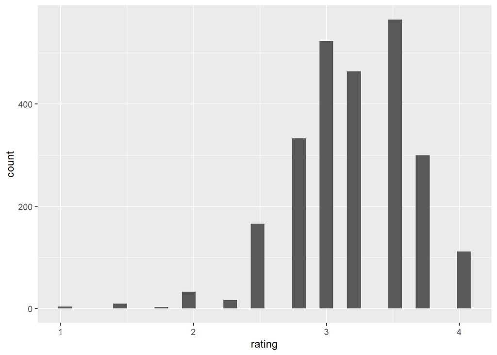

```r
#hist(chocolate$rating )
ggplot(chocolate,aes(rating ) ) +
  geom_histogram()
```

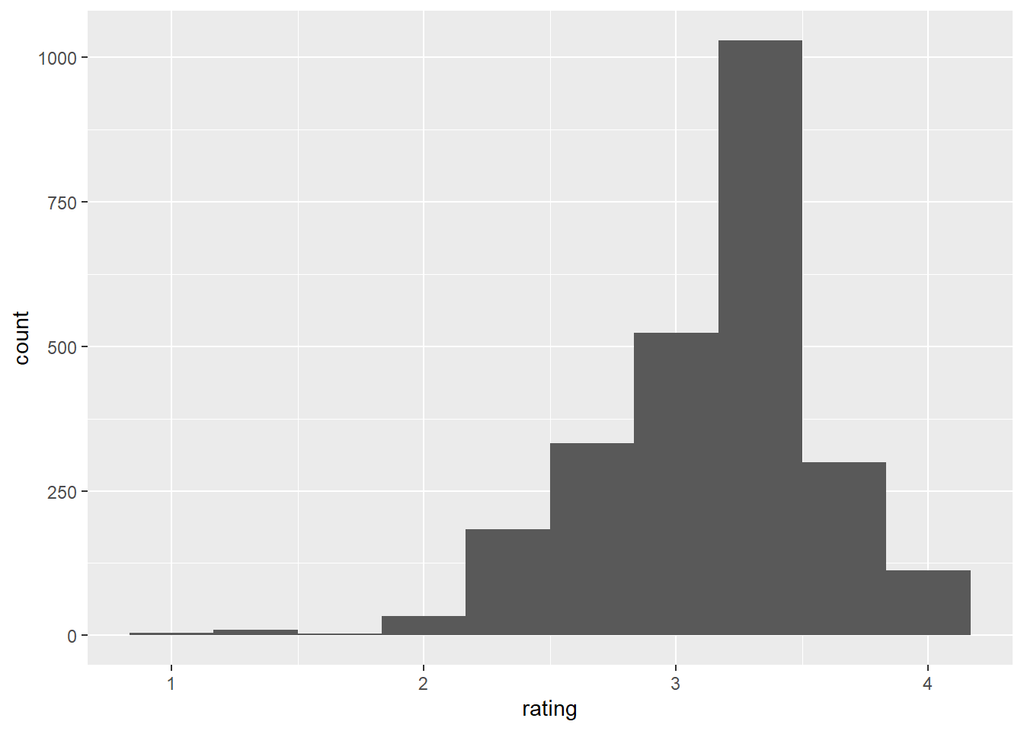

```r
ggplot(chocolate,aes(rating ) ) +
  geom_histogram(bins = 10)
```

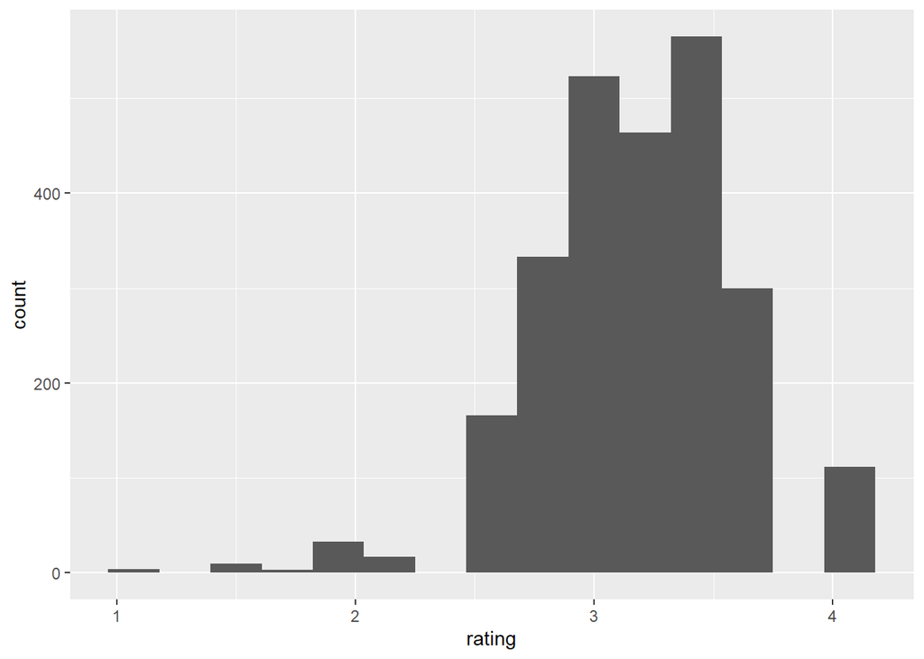

```r
ggplot(chocolate,aes(rating ) ) +
  geom_histogram(bins = 15)
```

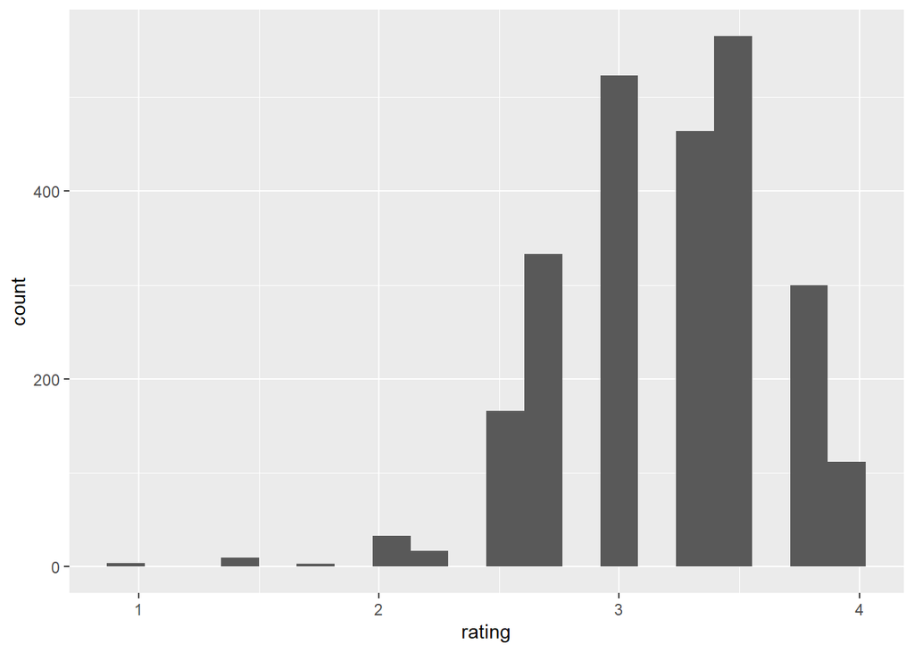

```r
ggplot(chocolate,aes(rating ) ) +
  geom_histogram(bins = 20)
```

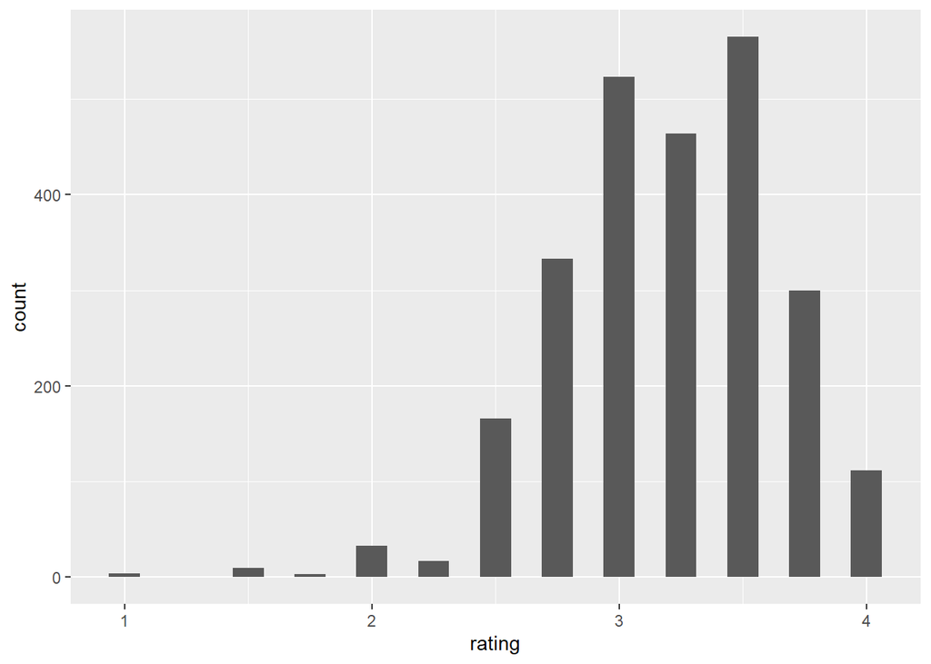

```r
ggplot(chocolate,aes(rating ) ) +
  geom_histogram(bins = 25)
```

I choose to use 15. Because the graph looked more smoother and didn’t have too many blank intervals. The default bins is 30. The number of bins (n) means how many groups the data is divided into. If I changed the number of bins, I changed the intervals between different groups. In this question, When I increased the bins number, the bin width decreased and the data was divided into more groups with smaller intervals, made the histogram plot looked more detailed and disperse. When I decreased the bins number, the bin width increased and the data was divided into less groups. The histogram looked smoother.

## Q2

Consider the countries where the beans originated from. How many reviews come from each country of bean origin?

```r
n_reviews <- chocolate %>%
  group_by(country_of_bean_origin) %>%
  summarise(
  number = n()
  )
n_reviews
```

```
## # A tibble: 62 × 2
##    country_of_bean_origin number
##    <chr>                   <int>
##  1 Australia                   3
##  2 Belize                     76
##  3 Blend                     156
##  4 Bolivia                    80
##  5 Brazil                     78
##  6 Burma                       1
##  7 Cameroon                    3
##  8 China                       1
##  9 Colombia                   79
## 10 Congo                      11
## # … with 52 more rows
```

From above table, we could see the number of reviews come from each country of bean origin.

## Q3

```r
chocolate %>%
  filter(country_of_bean_origin == "Ecuador") %>%
  summarise(
    mean = mean(rating),
    sd = sd(rating),
    total = n()
  )
```

```
## # A tibble: 1 × 3
##    mean    sd total
##   <dbl> <dbl> <int>
## 1  3.16 0.512   219
```

## Q4

```r
Country_rating <- chocolate %>%
  filter(country_of_bean_origin == "Ecuador") %>%
  group_by(company_manufacturer ) %>%
  summarise(
  mean = mean(rating)
  )

Country_rating <- arrange(Country_rating, desc(mean))
head(Country_rating)
```

```
## # A tibble: 6 × 2
##   company_manufacturer    mean
##   <chr>                  <dbl>
## 1 Amano                   4
## 2 Benoit Nihant           4
## 3 Beschle (Felchlin)      4
## 4 Durci                   4
## 5 Smooth Chocolator, The  4
## 6 Domori                  3.88
```

Amano, Benoit Nihant, Beschle (Felchlin), Durci and Smooth Chocolator, The make the best chocolate with beans from Ecuador.

## Q5

```r
average_rating <- chocolate %>%
  group_by(country_of_bean_origin) %>%
  summarise(
    mean = mean(rating)
  )

average_rating <- arrange(average_rating, desc(mean))
head(average_rating, 3)
```

```
## # A tibble: 3 × 2
##   country_of_bean_origin  mean
##   <chr>                  <dbl>
## 1 Tobago                  3.62
## 2 China                   3.5
## 3 Sao Tome & Principe     3.5
```

The top 3 countries have the highest ratings on average are Tobago, China, and Sao Tome & Principe.

## Q6

```r
review_number_10 <- chocolate %>%
  group_by(country_of_bean_origin) %>%
  mutate(
    review_number = n()  ) %>%
  filter( review_number >= 10 )

average_rating_10 <- review_number_10 %>%
  group_by(country_of_bean_origin) %>%
  summarise(
    mean = mean(rating)
  )

average_rating_10 <- arrange(average_rating_10, desc(mean))
head(average_rating_10, 3)
```

```
## # A tibble: 3 × 2
##   country_of_bean_origin  mean
##   <chr>                  <dbl>
## 1 Solomon Islands         3.45
## 2 Congo                   3.32
## 3 Cuba                    3.29
```

The top 3 countries have the highest ratings on average are Solomon Islands, Congo, and Cuba.

## Q7

```r
library(tidyr)
library(lubridate)
review_number_50 <- chocolate %>%
  group_by(country_of_bean_origin) %>%
  mutate(
    review_number_50 = n()
  ) %>%
  filter(review_number_50 >= 50)

review_number_50 <- review_number_50 %>%
  mutate(percent = as.numeric(substr(cocoa_percent, 1 , nchar(cocoa_percent) - 1 ))) %>%
  mutate(
    chocolate_group = case_when(
      percent < 60 ~ "<60%",
      percent < 70 & percent >= 60 ~ ">=60 to 70%",
      percent < 90 & percent >= 70 ~ ">=70 to 90%",
      percent >= 90 ~ ">= 90%"
    )
  )
```

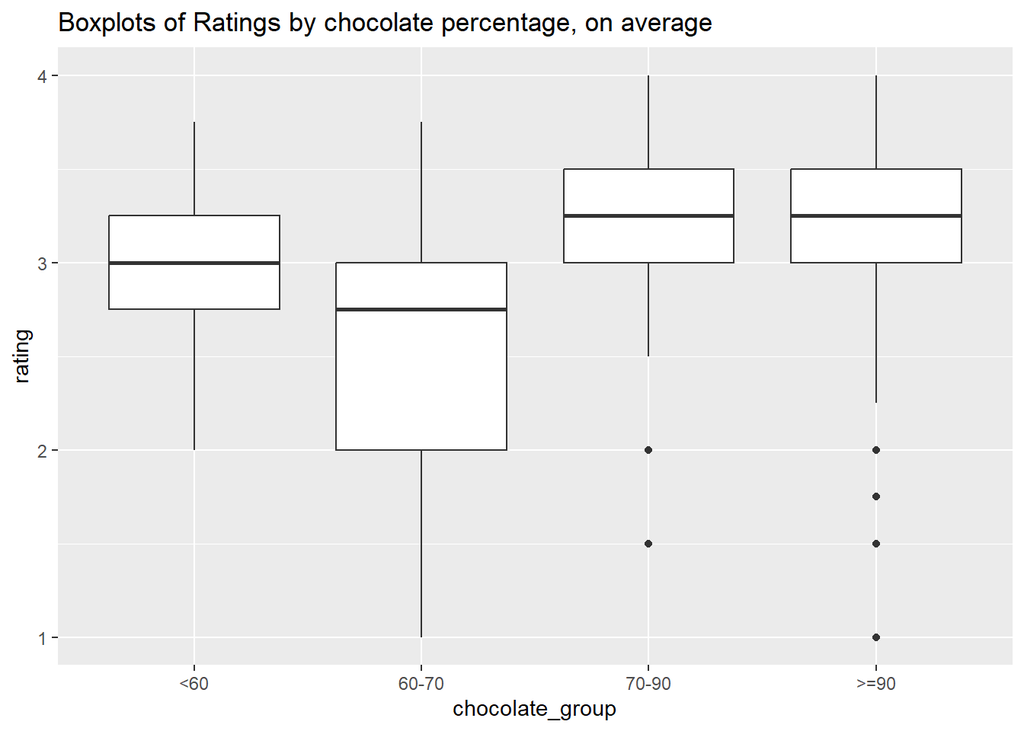

```r
ggplot(review_number_50, aes(chocolate_group, rating )) +
  geom_boxplot() +
  labs(title = "Boxplots of Ratings by chocolate percentage, on average") +
  scale_x_discrete(labels = c("<60", "60-70", "70-90", ">=90")  )
```

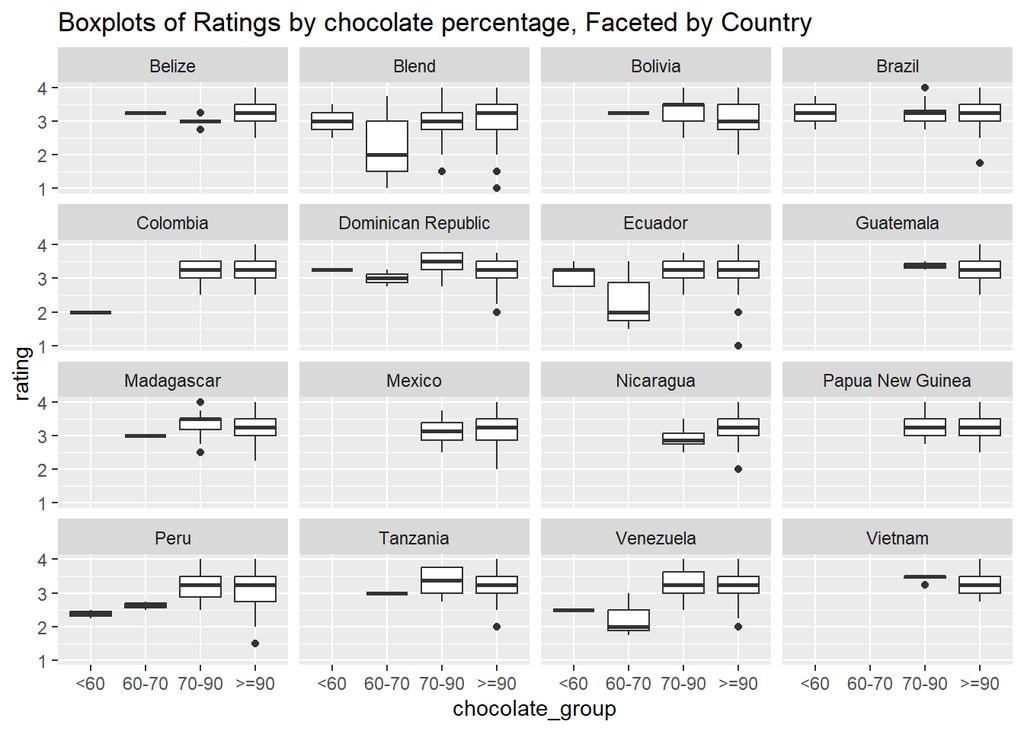

```r
ggplot(review_number_50, aes(chocolate_group, rating )) +
  geom_boxplot() +
  facet_wrap(~country_of_bean_origin, ncol = 4) +
  labs(title = "Boxplots of Ratings by chocolate percentage, Faceted by Country") +
  scale_x_discrete(labels = c("<60", "60-70", "70-90", ">=90")  )
```

### Q7: On average, which category of chocolate percentage is most highly rated? Do these countries mostly agree or are there disagreements?

```r
review_number_50 %>%
  group_by(chocolate_group ) %>%
  summarise(
    mean = mean(rating),
    number = n( )
  )
```

```
## # A tibble: 4 × 3
##   chocolate_group  mean number
##   <chr>           <dbl>  <int>
## 1 <60%             2.96     23
## 2 >= 90%           2.49     32
## 3 >=60 to 70%      3.25    270
## 4 >=70 to 90%      3.22   1682
```

# Part 2 Join two datasets together

```r
library(gapminder)
gapminder_data <- gapminder

# Identify duplicate rows based on the continent column
duplicates <- duplicated(gapminder_data[, 1])

# Create a new data frame without duplicates
gapminder_no_dup <- gapminder_data[!duplicates, ]

# left_join
chocolate_new <- chocolate %>%
  left_join(gapminder_no_dup, by = c("country_of_bean_origin" = "country") ) %>%
  group_by( country_of_bean_origin ) %>%
  mutate(
    review_number_10 = n()
  ) %>%
  filter(
    review_number_10 >= 10
  ) %>%
  ungroup() %>%
  filter(
    country_of_bean_origin != "Blend"
  )


# Identify NAs in the continent column
Na_country <- chocolate_new$country_of_bean_origin[is.na(chocolate_new$continent)]

table(Na_country)
```

```
## Na_country
##           Belize            Congo             Fiji          Grenada
##               76               11               16               19
## Papua New Guinea         Sao Tome  Solomon Islands        St. Lucia
##               50               14               10               10
##         Trinidad           U.S.A.          Vanuatu
##               42               33               13
```

```r
table(chocolate_new$continent)
```

```
##
##   Africa Americas     Asia   Europe  Oceania
##      316     1530      152        0        0
```

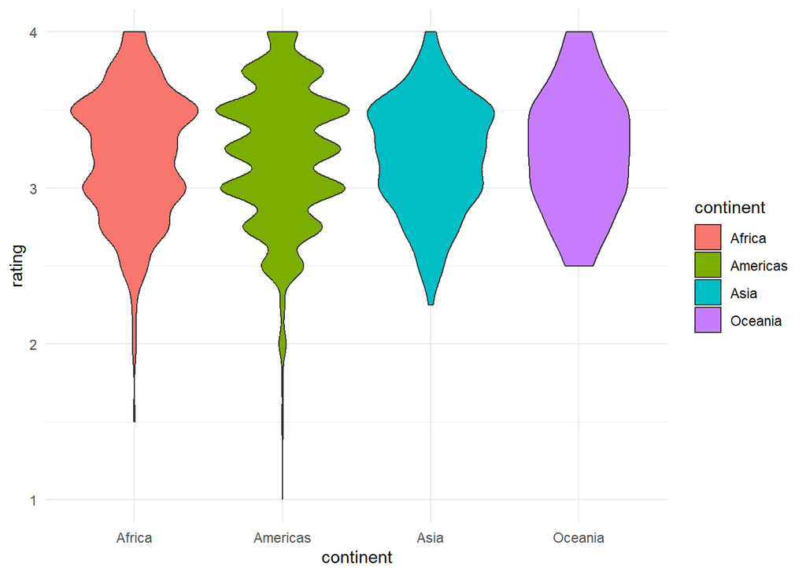

```r
# Replace NAs with continent values
# Create a mapping between countries and continents using a named vector
country_to_continent <- c(
  "Belize" = "Americas",
  "Congo" = "Africa",
  "Fiji" = "Oceania",
  "Grenada" = "Africa",
  "Papua New Guinea" = "Oceania",
  "Sao Tome" = "Africa",
  "Solomon Islands" = "Oceania",
  "St. Lucia" = "Americas",
  "Trinidad" = "Americas",
  "U.S.A." = "Americas",
  "Vanuatu" = "Oceania"
)

# replace the NA based on the mapping, retaining original values
chocolate_new <- chocolate_new %>%
  mutate(continent = as.character(continent)) %>%
  mutate(continent = ifelse(country_of_bean_origin %in% names(country_to_continent),                          country_to_continent[country_of_bean_origin],
                            continent))

chocolate_new %>%
  ggplot(aes(continent, rating) ) +
  geom_violin( aes(fill = continent )) +
  theme_minimal()
```

# Project 3 Convert wide data into long data

# Do we need to delete NAs?

```r
library(tidyr)
library(stringr)

chocolate_ingredients <- chocolate %>%
  mutate(
    beans = ifelse(str_detect(ingredients, "B"), 1, 0),
    sugar = ifelse(str_detect(ingredients, "S"), 1, 0),
    cocoa_butter = ifelse(str_detect(ingredients, "C"), 1, 0),
    vanilla = ifelse(str_detect(ingredients, "V"), 1, 0),
    letchin = ifelse(str_detect(ingredients, "L"), 1, 0),
    salt = ifelse(str_detect(ingredients, "Sa"), 1, 0),
  )

chocolate_ingredients <- chocolate_ingredients %>%
  mutate(
    char_cocoa = ifelse(str_detect(most_memorable_characteristics, "cocoa"), 1, 0),
    char_sweet = ifelse(str_detect(most_memorable_characteristics, "sweet"), 1, 0),
    char_nutty = ifelse(str_detect(most_memorable_characteristics, "nutty"), 1, 0),
    char_creamy = ifelse(str_detect(most_memorable_characteristics, "creamy"), 1, 0),
    char_roasty = ifelse(str_detect(most_memorable_characteristics, "roasty"), 1, 0),
    char_earthy = ifelse(str_detect(most_memorable_characteristics, "earthy"), 1, 0),
  )

widedata <- chocolate_ingredients %>%
  group_by(review_date) %>%
  summarise(
    mean_score_beans = mean(beans, na.rm = TRUE),
    mean_score_sugar = mean(sugar, na.rm = TRUE),
    mean_score_cocoa_butter = mean(cocoa_butter, na.rm = TRUE),
    mean_score_vanilla = mean(vanilla, na.rm = TRUE),
    mean_score_letchin = mean(letchin, na.rm = TRUE),
    mean_score_salt = mean(salt, na.rm = TRUE),
    mean_score_char_cocoa = mean(char_cocoa, na.rm = TRUE),
    mean_score_char_sweet = mean(char_sweet, na.rm = TRUE),
    mean_score_char_nutty = mean(char_nutty, na.rm = TRUE),
    mean_score_char_creamy = mean(char_creamy, na.rm = TRUE),
    mean_score_char_roasty = mean(char_roasty, na.rm = TRUE),
    mean_score_char_earthy = mean(char_earthy, na.rm = TRUE),
  )


longdata <- widedata %>%
  pivot_longer(
    cols = starts_with("mean_score_"),
    names_to = "feature",
    names_prefix = "mean_score_",
    values_to = "mean_score",
    values_drop_na = FALSE
  )
```

# Part 4 Data visualization

```r
str(longdata)
```

```
## tibble [192 × 3] (S3: tbl_df/tbl/data.frame)
##  $ review_date: num [1:192] 2006 2006 2006 2006 2006 ...
##  $ feature    : chr [1:192] "beans" "sugar" "cocoa_butter" "vanilla" ...
##  $ mean_score : num [1:192] 1 1 0.933 0.717 0.717 ...
```

```r
table(longdata$feature)
```

```
##
##        beans   char_cocoa  char_creamy  char_earthy   char_nutty  char_roasty
##           16           16           16           16           16           16
##   char_sweet cocoa_butter      letchin         salt        sugar      vanilla
##           16           16           16           16           16           16
```

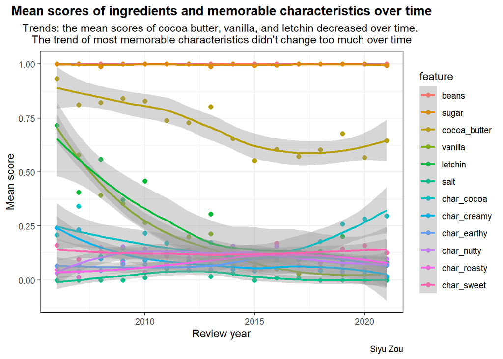

```r
longdata$feature <-
  factor(as.character(longdata$feature), levels = c("beans","sugar", "cocoa_butter", "vanilla", "letchin", "salt", "char_cocoa", "char_creamy", "char_earthy", "char_nutty", "char_roasty", "char_sweet" ) )

longdata %>%
  ggplot(aes(review_date, mean_score, color = feature)) +
  geom_point(  size = 2, alpha = 2 ) +
  geom_smooth(  linewidth = 1,method = 'loess' ) +
  labs(
    title = "Mean scores of ingredients and memorable characteristics over time",
    subtitle = "Trends: the mean scores of cocoa butter, vanilla, and letchin decreased over time. \nThe trend of most memorable characteristics didn't change too much over time",
    caption = "Siyu Zou",
    x = "Review year",
    y = "Mean score"
  ) +
  theme_bw() +
  theme(
    plot.title = element_text(hjust = 0.5, face = "bold", size = 13) ,
    plot.subtitle = element_text(hjust = 0.5, size = 11) ,
    plot.background = element_rect(fill = "white" ),
    axis.title = element_text(size = 11)
  )
```

# Part 5: Make the worst plot you can!

```r
str(review_number_50)
```

```
## gropd_df [2,007 × 13] (S3: grouped_df/tbl_df/tbl/data.frame)
##  $ ref                             : num [1:2007] 2454 2458 2454 2546 797 ...
##  $ company_manufacturer            : chr [1:2007] "5150" "5150" "5150" "5150" ...
##  $ company_location                : chr [1:2007] "U.S.A." "U.S.A." "U.S.A." "U.S.A." ...
##  $ review_date                     : num [1:2007] 2019 2019 2019 2021 2012 ...
##  $ country_of_bean_origin          : chr [1:2007] "Tanzania" "Dominican Republic" "Madagascar" "Venezuela" ...
##  $ specific_bean_origin_or_bar_name: chr [1:2007] "Kokoa Kamili, batch 1" "Zorzal, batch 1" "Bejofo Estate, batch 1" "Sur del Lago, batch 1" ...
##  $ cocoa_percent                   : chr [1:2007] "76%" "76%" "76%" "72%" ...
##  $ ingredients                     : chr [1:2007] "3- B,S,C" "3- B,S,C" "3- B,S,C" "3- B,S,C" ...
##  $ most_memorable_characteristics  : chr [1:2007] "rich cocoa, fatty, bready" "cocoa, vegetal, savory" "cocoa, blackberry, full body" "fatty, earthy, moss, nutty,chalky" ...
##  $ rating                          : num [1:2007] 3.25 3.5 3.75 3 3.5 3.75 2.75 3 3.25 3.25 ...
##  $ review_number_50                : int [1:2007] 79 226 177 253 80 244 79 177 78 50 ...
##  $ percent                         : num [1:2007] 76 76 76 72 70 63 70 70 70 70 ...
##  $ chocolate_group                 : chr [1:2007] ">=70 to 90%" ">=70 to 90%" ">=70 to 90%" ">=70 to 90%" ...
##  - attr(*, "groups")= tibble [16 × 2] (S3: tbl_df/tbl/data.frame)
##   ..$ country_of_bean_origin: chr [1:16] "Belize" "Blend" "Bolivia" "Brazil" ...
##   ..$ .rows                 : list<int> [1:16]
##   .. ..$ : int [1:76] 67 90 103 148 171 172 173 188 203 209 ...
##   .. ..$ : int [1:156] 73 75 81 82 141 143 179 200 210 218 ...
##   .. ..$ : int [1:80] 5 44 45 47 89 117 166 248 271 280 ...
##   .. ..$ : int [1:78] 9 32 83 84 85 86 87 96 98 123 ...
##   .. ..$ : int [1:79] 7 118 130 131 138 208 289 290 291 303 ...
##   .. ..$ : int [1:226] 2 43 52 58 69 88 100 112 127 139 ...
##   .. ..$ : int [1:219] 13 28 29 38 50 59 61 62 74 93 ...
##   .. ..$ : int [1:62] 91 97 109 201 211 213 265 272 278 279 ...
##   .. ..$ : int [1:177] 3 8 31 36 54 68 78 94 114 125 ...
##   .. ..$ : int [1:55] 23 26 30 37 92 134 151 227 228 238 ...
##   .. ..$ : int [1:100] 39 49 104 111 119 120 121 122 187 206 ...
##   .. ..$ : int [1:50] 10 60 70 144 163 320 357 358 513 514 ...
##   .. ..$ : int [1:244] 6 11 12 15 19 20 22 24 25 27 ...
##   .. ..$ : int [1:79] 1 40 110 133 136 137 149 167 216 249 ...
##   .. ..$ : int [1:253] 4 14 16 17 18 21 33 42 53 55 ...
##   .. ..$ : int [1:73] 35 41 107 108 115 129 169 170 174 326 ...
##   .. ..@ ptype: int(0)
##   ..- attr(*, ".drop")= logi TRUE
```

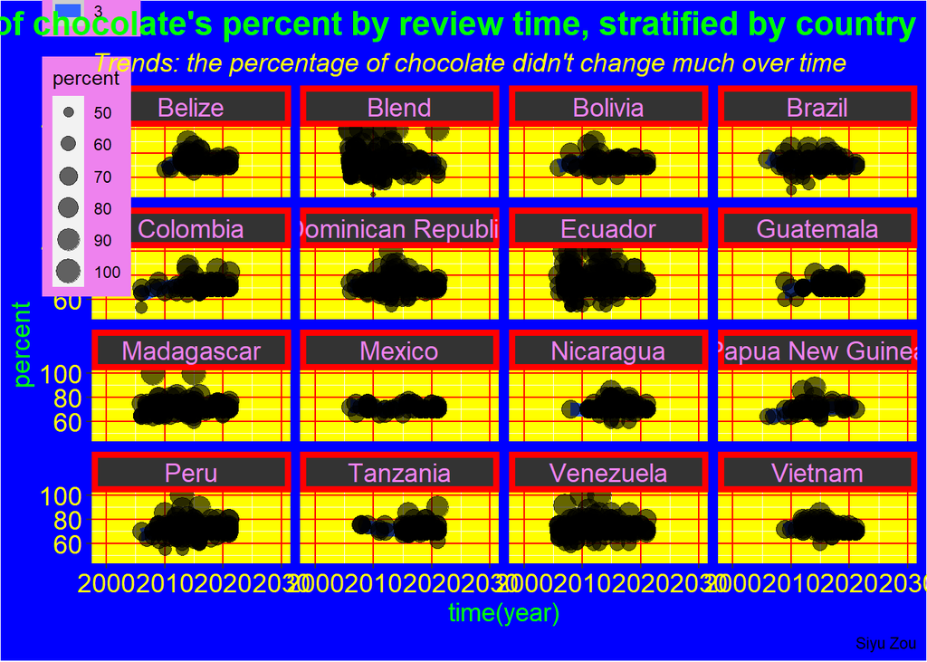

```r
review_number_50 %>%
  ggplot(aes( review_date , percent)) +
  geom_smooth(aes(linewidth = 3)) +
  geom_point(aes( size = percent), alpha = 0.6) +  #  make a "bubblechart"
  facet_wrap( ~ country_of_bean_origin ) +
  labs(
    title = "Trends of chocolate's percent by review time, stratified by country",
    subtitle = "Trends: the percentage of chocolate didn't change much over time",
    caption = "Siyu Zou",
    x = "time(year)",
    y = "percent"
  ) +
  coord_cartesian(xlim = c(1999, 2030)) +   # change the scale of the x axis to ranged from 1990 to 2030, which is larger than the real time range
  theme(
    strip.text = element_text(color = "violet", size = 14),   # change facets' title text
    strip.background = element_rect(fill = "grey20", color = "red", linewidth = 3  ),  # affect the background of panel strips

    plot.title = element_text(hjust = 1, color = "green", face = "bold", size = 18) ,  # change the plot title's position, color, size
    plot.subtitle = element_text(hjust = 0, color = "yellow", face = "italic", size = 14) ,  # change subtitle's position, color, size
    plot.background = element_rect(fill = "blue" ),  # change the plot background's color

    panel.background = element_rect(fill = "yellow"),  # change the panel color
    panel.grid.major = element_line(colour = "red", linewidth = 0.5),  # Change the major gridlines' color to red.

    legend.background = element_rect( fill = "violet" ),  # Chnge the legend' background color to violet
    legend.position = c(0, 1),

    axis.title = element_text(color = "green",size = 14),  # change the axis title color and size
    axis.text = element_text(color = "yellow", size = 14)   # change the axis text color and size
  )
```

# Part 6: Make a better plot you can!

```r
table(review_number_50$review_date)
```

```
##
## 2006 2007 2008 2009 2010 2011 2012 2013 2014 2015 2016 2017 2018 2019 2020 2021
##   51   61   78  101   82  120  162  146  210  235  180   80  176  133   66  126
```

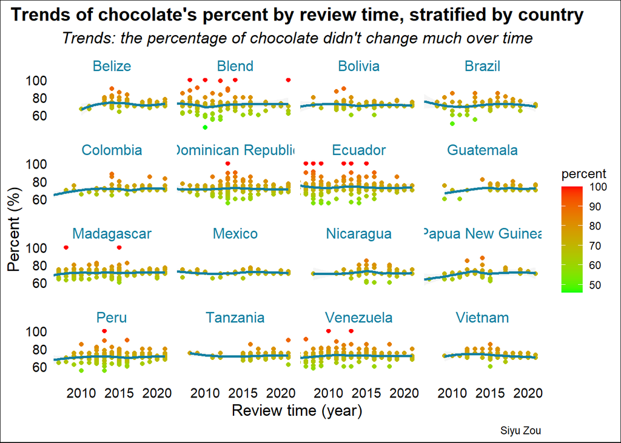

```r
review_number_50 %>%
  ggplot(aes( review_date , percent)) +
  geom_point(aes( color = percent), alpha = 2) +
  scale_color_gradient(low = "green", high = "red") +  # set color gradient for the "percent" variable, it's better to visualize the percentage values with a color scale from "green" to "red"
  geom_smooth( color = "#1380A1", alpha = 0.1 ) +
  facet_wrap( ~ country_of_bean_origin ) +
  labs(
    title = "Trends of chocolate's percent by review time, stratified by country",
    subtitle = "Trends: the percentage of chocolate didn't change much over time",
    caption = "Siyu Zou",
    x = "Review time (year)",
    y = "Percent (%)"
  ) +
  coord_cartesian(xlim = c(2007, 2021)) +  # Change the x axis scale to an appropriate range without delete observations
  theme_minimal() +   # make a very clean plot, setting the plot theme to a minimalistic style with a white background and no gridlines
  theme(
    text = element_text( family = "sans" ),  # Change the plot's font style to "sans".
    strip.text = element_text(color = "#1380A1" , size = 12),  #  Change the facets' title text to a beautiful blue color with appropriate size
    strip.background = element_rect(fill = "white", color = "white", linewidth = 1  ),

    plot.title = element_text(hjust = 0.5, color = "black", face = "bold", size = 15) ,  # controls the appearance of the plot title, set the font size to 15, with black color and bold face, "hjust = 0.5" means put the title on the middle
    plot.subtitle = element_text(hjust = 0.5, color = "black", face = "italic", size = 13) , # put the plot title on the middle
    plot.background = element_rect(fill = "white" ),

    panel.grid.major = element_line(color = "white", linewidth = 0.5),
    panel.grid.minor = element_line(color = "white"),

    axis.title = element_text(color = "black",size = 13),
    axis.text = element_text(color = "black", size = 11)
  )
```

- Add the aesthetic color in geom_point. Then by using scale_color_gradient(), I set color gradient for the “percent” variable, it’s better to visualize the percentage values with a color scale from “green” to “red”.
- Stratify the plot by country, using “facet_wrap( ~ country_of_bean_origin )”, make the plot more clear and comparable.
- Change the x axis scale to an appropriate range without delete observations by using coord_cartesian(xlim = c(2007, 2021)).
- Use theme_minimal() to make a very clean plot, setting the plot theme to a minimalistic style with a white background and no gridlines.
- Change the plot’s font style to “sans”.
- Change the facets’ title text to a beautiful blue color with appropriate size: strip.text = element_text(color = “#1380A1” , size = 12)
- The plot.title element controls the appearance of the plot title, set the font size to 15, with black color and bold face, “hjust = 0.5” means put the title on the middle.
- Similarly, put the subtitle on the middle of the plot, set the font size to 13, with black color, and italic face.
- Put the legend on the right middle and outside the plot, without adjusting the plot.